# Assignment Week 2

Ruqia Ali Hassan

2025-02-28

# Loading Librarys

```r
suppressPackageStartupMessages({ #in order not to get the messages, for cleaner markdown
  library(AnnotationHub) # to fetch genomes, annotations, etc.
  library(ensembldb)     # to manipulate ensembl gene annotations
  library(GenomicRanges) # data structure for genomic ranges
  library(epiwraps)      # visualization
})

ah<-AnnotationHub()
```

All the relevant libraries are loaded, and `ah` is initialized.

## Downloading annotations data

```r
#Download the mouse (Mus Musculus) EnsDb object, version 102, genome build GRCm38
mouse <- query(ah, c("EnsDb", "Mus musculus", "102", "GRCm38"))

#Download the mouse genome sequence ( dna_sm ) in TwoBit/2bit format for GRCm38
mouse_gs <- query(ah, c("Mus musculus", "dna_sm", "TwoBit", "GRCm38"))

#Download the drosophila melanogaster genome sequence ( dna_sm ) in TwoBit/2bit format for BDGP6
drosophila_melanogaster <- query(ah, c("Drosophila melanogaster", "dna_sm", "TwoBit", "BDGP6"))
```

Using `query()`, we download the three required annotation datasets: - The mouse (Mus musculus) —-EnsDb object, version 102, genome build GRCm38 - The mouse genome sequence (dna_sm) in TwoBit/2bit format for GRCm38 - The Drosophila melanogaster genome sequence (dna_sm) in TwoBit/2bit format for BDGP6

### Mouse EnsDb

```r
mouse
```

```
## AnnotationHub with 1 record
## # snapshotDate(): 2024-10-28
## # names(): AH89211
## # $dataprovider: Ensembl
## # $species: Mus musculus
## # $rdataclass: EnsDb
## # $rdatadateadded: 2020-10-27
## # $title: Ensembl 102 EnsDb for Mus musculus
## # $description: Gene and protein annotations for Mus musculus based on Ensem...
## # $taxonomyid: 10090
## # $genome: GRCm38
## # $sourcetype: ensembl
## # $sourceurl: http://www.ensembl.org
## # $sourcesize: NA
## # $tags: c("102", "AHEnsDbs", "Annotation", "EnsDb", "Ensembl", "Gene",
## #   "Protein", "Transcript")
## # retrieve record with 'object[["AH89211"]]'
```

```r
ensdb<- ah[["AH89211"]]
```

```
## loading from cache
```

```r
genes <- genes(ensdb)
head(genes)
```

```
## GRanges object with 6 ranges and 9 metadata columns:
##                      seqnames          ranges strand |            gene_id
##                         <Rle>       <IRanges>  <Rle> |        <character>
##   ENSMUSG00000102693        1 3073253-3074322      + | ENSMUSG00000102693
##   ENSMUSG00000064842        1 3102016-3102125      + | ENSMUSG00000064842
##   ENSMUSG00000051951        1 3205901-3671498      - | ENSMUSG00000051951
##   ENSMUSG00000102851        1 3252757-3253236      + | ENSMUSG00000102851
##   ENSMUSG00000103377        1 3365731-3368549      - | ENSMUSG00000103377
##   ENSMUSG00000104017        1 3375556-3377788      - | ENSMUSG00000104017
##                          gene_name         gene_biotype seq_coord_system
##                        <character>          <character>      <character>
##   ENSMUSG00000102693 4933401J01Rik                  TEC       chromosome
##   ENSMUSG00000064842       Gm26206                snRNA       chromosome
##   ENSMUSG00000051951          Xkr4       protein_coding       chromosome
##   ENSMUSG00000102851       Gm18956 processed_pseudogene       chromosome
##   ENSMUSG00000103377       Gm37180                  TEC       chromosome
##   ENSMUSG00000104017       Gm37363                  TEC       chromosome
##                                 description      gene_id_version
##                                 <character>          <character>
##   ENSMUSG00000102693 RIKEN cDNA 4933401J0.. ENSMUSG00000102693.1
##   ENSMUSG00000064842 predicted gene, 2620.. ENSMUSG00000064842.1
##   ENSMUSG00000051951 X-linked Kx blood gr.. ENSMUSG00000051951.5
##   ENSMUSG00000102851 predicted gene, 1895.. ENSMUSG00000102851.1
##   ENSMUSG00000103377 predicted gene, 3718.. ENSMUSG00000103377.1
##   ENSMUSG00000104017 predicted gene, 3736.. ENSMUSG00000104017.1
##                      canonical_transcript        symbol entrezid
##                               <character>   <character>   <list>
##   ENSMUSG00000102693   ENSMUST00000193812 4933401J01Rik     <NA>
##   ENSMUSG00000064842   ENSMUST00000082908       Gm26206     <NA>
##   ENSMUSG00000051951   ENSMUST00000070533          Xkr4   497097
##   ENSMUSG00000102851   ENSMUST00000192857       Gm18956     <NA>
##   ENSMUSG00000103377   ENSMUST00000195335       Gm37180     <NA>
##   ENSMUSG00000104017   ENSMUST00000192336       Gm37363     <NA>
##   -------
##   seqinfo: 118 sequences (1 circular) from GRCm38 genome
```

```r
#Number of different ensembl gene IDs
num_geneID <- length(unique(genes$gene_id))
num_geneID
```

```
## [1] 56305
```

```r
#Number of different ensembl gene symbols
num_genesymbol <- length(unique(genes$gene_name))
num_genesymbol
```

```
## [1] 55494
```

```r
# exons of protein-coding transcripts
exsPerTx<- exonsBy(ensdb, by="tx", filter=TxBiotypeFilter("protein_coding"))
exsPerTx
```

```
## GRangesList object of length 60320:
## $ENSMUST00000000001
## GRanges object with 9 ranges and 3 metadata columns:
##       seqnames              ranges strand |            exon_id     tx_biotype
##          <Rle>           <IRanges>  <Rle> |        <character>    <character>
##   [1]        3 108145888-108146146      - | ENSMUSE00000334714 protein_coding
##   [2]        3 108123795-108123837      - | ENSMUSE00000276500 protein_coding
##   [3]        3 108123542-108123683      - | ENSMUSE00000276490 protein_coding
##   [4]        3 108118301-108118458      - | ENSMUSE00000276482 protein_coding
##   [5]        3 108115763-108115891      - | ENSMUSE00000565003 protein_coding
##   [6]        3 108112473-108112602      - | ENSMUSE00000565001 protein_coding
##   [7]        3 108111935-108112088      - | ENSMUSE00000565000 protein_coding
##   [8]        3 108109403-108109612      - | ENSMUSE00000404895 protein_coding
##   [9]        3 108107280-108109316      - | ENSMUSE00000363317 protein_coding
##       exon_rank
##       <integer>
##   [1]         1
##   [2]         2
##   [3]         3
##   [4]         4
##   [5]         5
##   [6]         6
##   [7]         7
##   [8]         8
##   [9]         9
##   -------
##   seqinfo: 104 sequences (1 circular) from GRCm38 genome
##
## $ENSMUST00000000003
## GRanges object with 7 ranges and 3 metadata columns:
##       seqnames            ranges strand |            exon_id     tx_biotype
##          <Rle>         <IRanges>  <Rle> |        <character>    <character>
##   [1]        X 77853409-77853623      - | ENSMUSE00000789955 protein_coding
##   [2]        X 77847975-77848114      - | ENSMUSE00000149241 protein_coding
##   [3]        X 77845019-77845086      - | ENSMUSE00000149240 protein_coding
##   [4]        X 77842897-77843007      - | ENSMUSE00000305668 protein_coding
##   [5]        X 77842515-77842616      - | ENSMUSE00000305663 protein_coding
##   [6]        X 77841860-77841911      - | ENSMUSE00000305655 protein_coding
##   [7]        X 77837901-77838114      - | ENSMUSE00000348782 protein_coding
##       exon_rank
```

[output cut: 11 more lines]

```
## $ENSMUST00000000010
## GRanges object with 2 ranges and 3 metadata columns:
##       seqnames            ranges strand |            exon_id     tx_biotype
##          <Rle>         <IRanges>  <Rle> |        <character>    <character>
##   [1]       11 96271457-96272058      + | ENSMUSE00000110976 protein_coding
##   [2]       11 96274624-96276595      + | ENSMUSE00000443026 protein_coding
##       exon_rank
##       <integer>
##   [1]         1
##   [2]         2
##   -------
##   seqinfo: 104 sequences (1 circular) from GRCm38 genome
##
## ...
## <60317 more elements>
```

```r
txLengths <- sum(width(exsPerTx))
head(txLengths)
```

```
## ENSMUST00000000001 ENSMUST00000000003 ENSMUST00000000010 ENSMUST00000000028
##               3262                902               2574               2143
## ENSMUST00000000033 ENSMUST00000000049
##               3708               1190
```

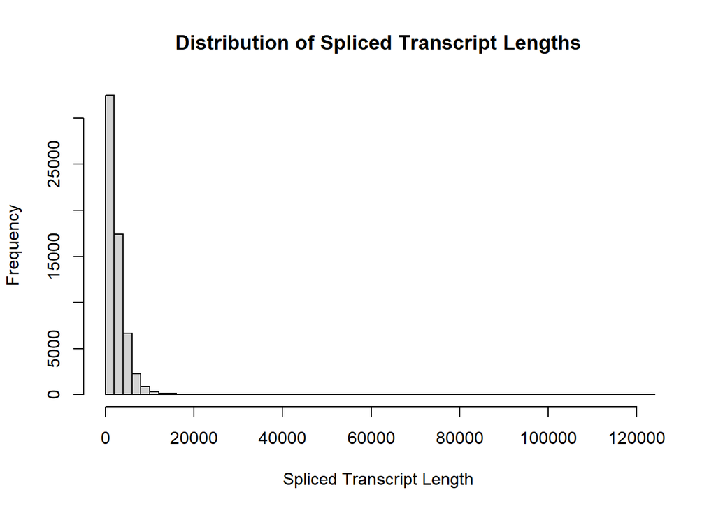

```r
hist(txLengths, breaks = 50, main = "Distribution of Spliced Transcript Lengths",
     xlab = "Spliced Transcript Length", xlim = range(txLengths))
```

Next, we take a closer look at the mouse EnsDb. Since there is only one record with the ID `AH89211`, we use `ensdb <- ah[["AH89211"]]`. Using the `genes()` function, we extract the genes and determine the number of unique Ensembl gene IDs and symbols.

After extracting the exons split by transcripts for the protein-coding regions of the genome using the exonsBy function, we group the exons by individual transcripts. These grouped exons are then summed to calculate the length of each transcript. Finally, the distribution of transcript lengths is visualized using a histogram.